# 時系列統計モデリング

```python
import pandas as pd
import matplotlib.pyplot as plt
import io
import requests
```

```python
# 飛行機乗客数データ
url = "https://www.analyticsvidhya.com/wp-content/uploads/2016/02/AirPassengers.csv"
stream = requests.get(url).content
content = pd.read_csv(io.StringIO(stream.decode('utf-8')), index_col='Month', parse_dates=True, dtype='float')
```

```python
content.head()
```

| Month | #Passengers |
| --- | --- |
| 1949-01-01 | 112.0 |
| 1949-02-01 | 118.0 |
| 1949-03-01 | 132.0 |
| 1949-04-01 | 129.0 |
| 1949-05-01 | 121.0 |

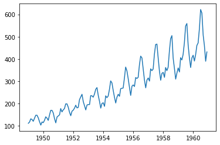

```python
passengers = content['#Passengers'][:120]
passengers_plot = content['#Passengers']
plt.plot(passengers_plot)
plt.show()
```

# ARモデル

### STEP1：単位根検定(ADF)による定常性確認、自己相関・偏自己相関の確認

```python
from statsmodels import api as s_api
```

```python
result = s_api.tsa.stattools.adfuller(passengers)
result
```

```
(-0.7734607708969391,
 0.8267937485032444,
 13,
 106,
 {'1%': -3.4936021509366793,
  '5%': -2.8892174239808703,
  '10%': -2.58153320754717},
 788.3190093041055)
```

```
ADF Statistic: -0.773461
p-value: 0.826794
critical Values:
臨界値	1%: -3.494
臨界値	5%: -2.889
臨界値	10%: -2.582
```

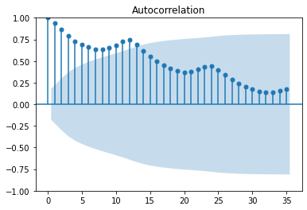

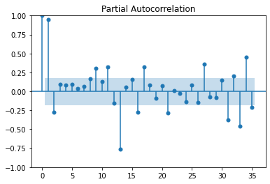

```python
print('ADF Statistic: %f' % result[0])
print('p-value: %f' % result[1])
print('critical Values:')
for key, value in result[4].items():
    print('臨界値\t%s: %.3f' % (key, value))
s_api.graphics.tsa.plot_acf(passengers, lags=35) # 自己相関表示
s_api.graphics.tsa.plot_pacf(passengers, lags=35) # 偏自己相関表示
plt.show()
```

- Autocorrelation図より、ラグ14まで自己相関係数が有意
- Partial Autocorrelation図より、ラグ1に大きな正の相関が、ラグ13に負の相関がある
- 検定結果も帰無仮説が棄却されないので、非定常性critical Values

## STEP2：残差に対する自己相関分析、偏自己相関分析

```python
from statsmodels import tsa
import warnings
warnings.filterwarnings('ignore')
```

```python
# ARのorder選択
for i in range(10):
    model = tsa.arima.model.ARIMA(passengers, order=(i+1, 0, 0)).fit()
    print('order ',i,"'s AIC: ", model.aic)
```

```
order  0 's AIC:  1152.396297381442
order  1 's AIC:  1141.9925064432778
order  2 's AIC:  1139.9350653758238
order  3 's AIC:  1140.2265748610776
order  4 's AIC:  1134.203504699284
order  5 's AIC:  1135.8411984200757
order  6 's AIC:  1136.4605246736808
order  7 's AIC:  1135.8717872323025
order  8 's AIC:  1107.879602446463
order  9 's AIC:  1107.1791284112683
```

```python
model = tsa.arima.model.ARIMA(passengers, order=(9, 0, 0)).fit()
```

```python
# 残差の確認
resid = model.resid
resid[:5]
```

```
Month
1949-01-01   -133.915443
1949-02-01      2.406346
1949-03-01      7.702516
1949-04-01     -9.751786
1949-05-01     -6.124980
dtype: float64
```

### 残差の自己相関と偏自己相関を可視化

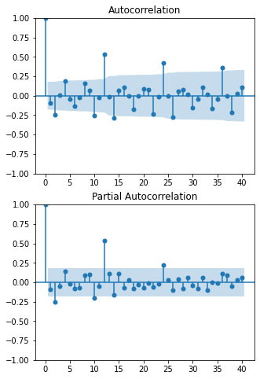

```python
fig = plt.figure(figsize=(5,8))
ax1 = fig.add_subplot(211)
fig = s_api.graphics.tsa.plot_acf(resid, lags=40, ax=ax1)
ax2 = fig.add_subplot(212)
fig = s_api.graphics.tsa.plot_pacf(resid, lags=40, ax=ax2)
```

- 上記のように、非定常性のデータをそのままARモデルに適用すると、相関が残差に現れる。
  - -> 逆に言えば、残差に相関が残っていることは、解析手法が元データに残っている非定常性を処理できていないことを示している。

## STEP3：ARモデルの予測値を実測値をプロット

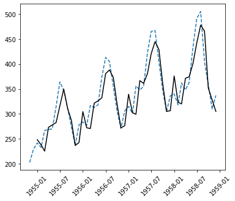

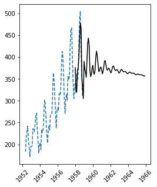

```python
pred = model.predict('1955-01-01', '1958-12-01')
plt.figure(figsize=(6,5))
plt.plot(passengers[70:120],'--')
plt.plot(pred, "k")
plt.xticks(rotation=45)

pred = model.predict('1958-01-01', '1965-12-01')
plt.figure(figsize=(4,5))
plt.plot(passengers[40:],'--')
plt.plot(pred, "k")
plt.xticks(rotation=45)

plt.show()
```

# MAモデル

## STEP1：サンプルデータに対するADF検定と、自己相関分析・偏自己相関分析

```python
# ARモデルでの結果を参照
```

## STEP2：残差に対する自己相関分析、偏自己相関分析

```python
# ARのorder選択
for i in range(10):
    model = tsa.arima.model.ARIMA(passengers, order=(0, 0, i+1)).fit()
    print('order ',i,"'s AIC: ", model.aic, "'s BIC: ", model.bic)
```

```
order  0 's AIC:  1295.4218464795822 's BIC:  1303.7843217079283
order  1 's AIC:  1229.2184917300697 's BIC:  1240.3684587011978
order  2 's AIC:  1169.7840864259215 's BIC:  1183.7215451398317
order  3 's AIC:  1191.7531165754308 's BIC:  1208.4780670321231
order  4 's AIC:  1146.1866048870752 's BIC:  1165.6990470865494
order  5 's AIC:  1194.8330506439975 's BIC:  1217.1329845862538
order  6 's AIC:  1117.6213797642388 's BIC:  1142.7088054492772
order  7 's AIC:  1142.0796507734246 's BIC:  1169.9545682012451
order  8 's AIC:  1120.9473864873762 's BIC:  1151.6097956579788
order  9 's AIC:  1130.2465217063082 's BIC:  1163.6964226196926
```

```python
model = tsa.arima.model.ARIMA(passengers, order=(0, 0, 6)).fit()
```

```python
resid = model.resid
resid
```

```
Month
1949-01-01   -133.762558
1949-02-01    -18.719800
1949-03-01    -31.972892
1949-04-01    -31.805934
1949-05-01    -17.076811
                 ...
1958-08-01     28.221216
1958-09-01    -29.780514
1958-10-01    104.049944
1958-11-01    -45.369312
1958-12-01     16.546870
Length: 120, dtype: float64
```

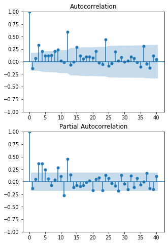

```python
fig = plt.figure(figsize=(5,8))
ax1 = fig.add_subplot(211)
fig = s_api.graphics.tsa.plot_acf(resid, lags=40, ax=ax1)
ax2 = fig.add_subplot(212)
fig = s_api.graphics.tsa.plot_pacf(resid, lags=40, ax=ax2)
```

- グラフより、残差のデータ同士はまだ相関が残っているのがわかる
- MA回帰条件は定常性を満たす必要があるため、非定常性のデータにそのままMAモデルを適用すると、相関を持った残差が表れる

## STEP3：MAモデルによる予測値と実測値をプロット

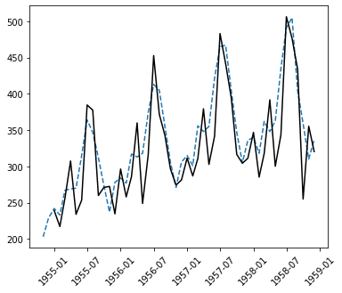

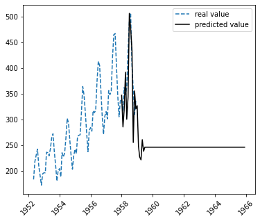

```python
pred = model.predict('1955-01-01', '1958-12-01')
plt.figure(figsize=(6,5))
plt.plot(passengers[70:120],'--', label='real value')
plt.plot(pred, "k", label='predicted value')
plt.xticks(rotation=45)

pred = model.predict('1958-01-01', '1965-12-01')
plt.figure(figsize=(6,5))
plt.plot(passengers[40:],'--', label='real value')
plt.plot(pred, "k", label='predicted value')
plt.xticks(rotation=45)
plt.legend()
plt.show()
```

- 予測にトレンドも周期性も全く反映されていない

# ARMAモデル

## STEP1：サンプルデータに対するADF検定と、自己相関分析・偏自己相関分析

```python
# ARモデルでの結果参照
```

## STEP2：残差に対する自己相関分析、偏自己相関分析

```python
# モデルの選定
sellected_order = tsa.stattools.arma_order_select_ic(passengers, max_ar=10, max_ma=10, ic='aic')
```

```python
# 選定結果
sellected_order.aic_min_order
```

```
(8, 9)
```

```python
model = tsa.arima.model.ARIMA(passengers, order=(8, 0, 9)).fit()
```

```python
resid = model.resid
resid
```

```
Month
1949-01-01   -133.909019
1949-02-01      3.168622
1949-03-01      7.120942
1949-04-01    -10.555256
1949-05-01      2.466391
                 ...
1958-08-01     37.732684
1958-09-01    -27.268864
1958-10-01      0.500663
1958-11-01    -22.223930
1958-12-01     17.949356
Length: 120, dtype: float64
```

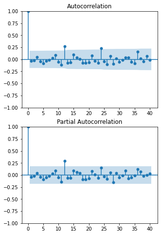

```python
fig = plt.figure(figsize=(5,8))
ax1 = fig.add_subplot(211)
fig = s_api.graphics.tsa.plot_acf(resid, lags=40, ax=ax1)
ax2 = fig.add_subplot(212)
fig = s_api.graphics.tsa.plot_pacf(resid, lags=40, ax=ax2)
```

- 残差に12周期ごとの自己相関がのこっている

## STEP3：ARMAモデルによる予測値と実測値をプロット

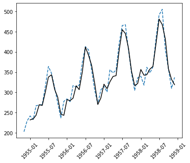

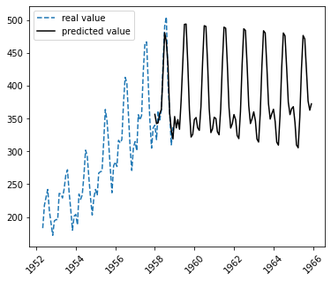

```python
pred = model.predict('1955-01-01', '1958-12-01')
plt.figure(figsize=(6,5))
plt.plot(passengers[70:120],'--', label='real value')
plt.plot(pred, "k", label='predicted value')
plt.xticks(rotation=45)

pred = model.predict('1958-01-01', '1965-12-01')
plt.figure(figsize=(6,5))
plt.plot(passengers[40:],'--', label='real value')
plt.plot(pred, "k", label='predicted value')
plt.xticks(rotation=45)
plt.legend()
plt.show()
```

- 周期性は捉えられるようになってきている
- トレンドが捉えられていない

# ARIMAモデル

## STEP1省略

## STEP2：残差に対する自己相関分析、偏自己相関分析

- ARIMAモデルのパラメータ探索は、まずデータを差分（微分）してから、arma_order_select_ic()で探索する

```python
import numpy as np
```

```python
# ARIMAのorder選択

# まずデータを差分して定常性にする
diffed_passengers = np.diff(passengers)
```

```python
diffed_passengers
```

```
array([   6.,   14.,   -3.,   -8.,   14.,   13.,    0.,  -12.,  -17.,
        -15.,   14.,   -3.,   11.,   15.,   -6.,  -10.,   24.,   21.,
          0.,  -12.,  -25.,  -19.,   26.,    5.,    5.,   28.,  -15.,
          9.,    6.,   21.,    0.,  -15.,  -22.,  -16.,   20.,    5.,
          9.,   13.,  -12.,    2.,   35.,   12.,   12.,  -33.,  -18.,
        -19.,   22.,    2.,    0.,   40.,   -1.,   -6.,   14.,   21.,
          8.,  -35.,  -26.,  -31.,   21.,    3.,  -16.,   47.,   -8.,
          7.,   30.,   38.,   -9.,  -34.,  -30.,  -26.,   26.,   13.,
         -9.,   34.,    2.,    1.,   45.,   49.,  -17.,  -35.,  -38.,
        -37.,   41.,    6.,   -7.,   40.,   -4.,    5.,   56.,   39.,
         -8.,  -50.,  -49.,  -35.,   35.,    9.,  -14.,   55.,   -8.,
          7.,   67.,   43.,    2.,  -63.,  -57.,  -42.,   31.,    4.,
        -22.,   44.,  -14.,   15.,   72.,   56.,   14., -101.,  -45.,
        -49.,   27.])
```

```python
# モデルの選定
sellected_order = tsa.stattools.arma_order_select_ic(diffed_passengers, max_ar=10, max_ma=10, ic='aic')
```

```python
# 選定結果
sellected_order.aic_min_order
```

```
(10, 4)
```

```python
# モデル
model = tsa.arima.model.ARIMA(passengers, order=(10, 1, 4)).fit()
```

```python
resid = model.resid
resid
```

```
Month
1949-01-01    112.000000
1949-02-01      5.979191
1949-03-01     13.533695
1949-04-01     -5.529943
1949-05-01    -11.400880
                 ...
1958-08-01     16.545189
1958-09-01    -43.245368
1958-10-01      8.969222
1958-11-01      6.587121
1958-12-01      2.746302
Length: 120, dtype: float64
```

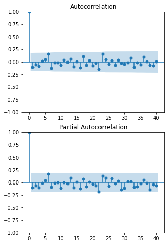

```python
fig = plt.figure(figsize=(5,8))
ax1 = fig.add_subplot(211)
fig = s_api.graphics.tsa.plot_acf(resid, lags=40, ax=ax1)
ax2 = fig.add_subplot(212)
fig = s_api.graphics.tsa.plot_pacf(resid, lags=40, ax=ax2)
```

## STEP3：ARIMAモデルによる予測値と実測値をプロット

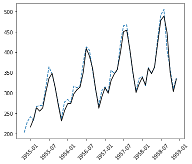

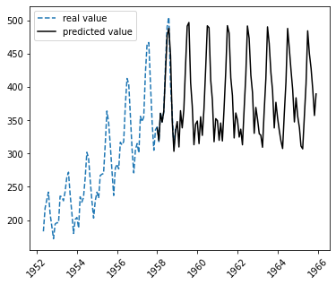

```python
pred = model.predict('1955-01-01', '1958-12-01')
plt.figure(figsize=(6,5))
plt.plot(passengers[70:120],'--', label='real value')
plt.plot(pred, "k", label='predicted value')
plt.xticks(rotation=45)

pred = model.predict('1958-01-01', '1965-12-01')
plt.figure(figsize=(6,5))
plt.plot(passengers[40:],'--', label='real value')
plt.plot(pred, "k", label='predicted value')
plt.xticks(rotation=45)
plt.legend()
plt.show()
```

- 過去データはかなり一致してきているが、予測に関してはARMAとあまり変わらない？

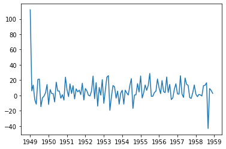

```python
# 残差のプロット
plt.plot(resid)
```

# SARIMAモデル

## STEP1省略

## STEP2：残差に対する自己相関分析、偏自己相関分析

- 今までの残差の自己相関から、12ごとの周期性があったので、seasonalに12を設定
- seasonalの(p,d,q)はとりあえず1で設定

```python
# モデル
model = tsa.statespace.sarimax.SARIMAX(passengers, order=(10,1,4), seasonal_order=(1,1,1,12)).fit()
```

```python
resid = model.resid
resid
```

```
Month
1949-01-01    112.000000
1949-02-01      6.002080
1949-03-01     13.999394
1949-04-01     -2.998547
1949-05-01     -7.999666
                 ...
1958-08-01     14.339924
1958-09-01    -32.845755
1958-10-01     -0.248593
1958-11-01     -2.495599
1958-12-01     -8.481652
Length: 120, dtype: float64
```

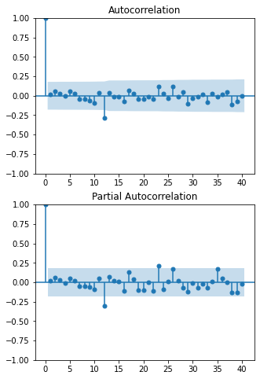

```python
fig = plt.figure(figsize=(5,8))
ax1 = fig.add_subplot(211)
fig = s_api.graphics.tsa.plot_acf(resid, lags=40, ax=ax1)
ax2 = fig.add_subplot(212)
fig = s_api.graphics.tsa.plot_pacf(resid, lags=40, ax=ax2)
```

## STEP3：SARIMAモデルによる予測値と実測値をプロット

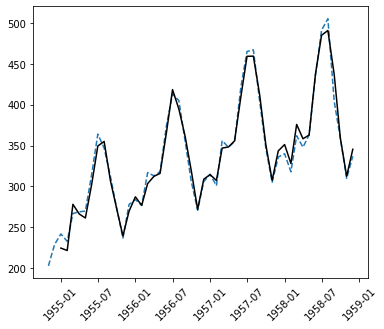

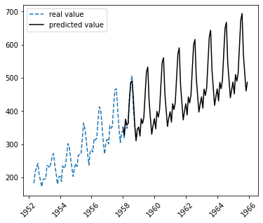

```python
pred = model.predict('1955-01-01', '1958-12-01')
plt.figure(figsize=(6,5))
plt.plot(passengers[70:120],'--', label='real value')
plt.plot(pred, "k", label='predicted value')
plt.xticks(rotation=45)

pred = model.predict('1958-01-01', '1965-12-01')
plt.figure(figsize=(6,5))
plt.plot(passengers[40:],'--', label='real value')
plt.plot(pred, "k", label='predicted value')
plt.xticks(rotation=45)
plt.legend()
plt.show()
```

- トレンドも考慮されるようになった

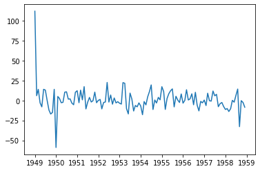

```python
# 残差のプロット
plt.plot(resid)
```